# Regression Models_project

weimf

1/5/2022

## Introduction

This project aims to explore the relationship between a set of variables and miles per gallon (MPG) (outcome). Specifically, I will address the following two questions:  
1. Is an automatic or manual transmission (am) better for MPG?  
2. Quantify the MPG difference between automatic and manual transmissions.

## Executive summary

This project finds that manual transmission alone seems to be better for MPG than the automatic one. However, after accounting for other factors such as the number of cylinders, gross horsepower, and weight that might also affect the performance of the cars, the transmission type is no longer significant in the multivariate model. Considerations on relevant factors as a whole shall be a more comprehensive way in determining the overall performance of the motors.

## Descriptive analysis

```r
library(datasets)
data(mtcars)

#View the dataset
head(mtcars, 3)
```

```
##                mpg cyl disp  hp drat    wt  qsec vs am gear carb
## Mazda RX4     21.0   6  160 110 3.90 2.620 16.46  0  1    4    4
## Mazda RX4 Wag 21.0   6  160 110 3.90 2.875 17.02  0  1    4    4
## Datsun 710    22.8   4  108  93 3.85 2.320 18.61  1  1    4    1
```

```r
summary(mtcars$mpg)
```

```
##    Min. 1st Qu.  Median    Mean 3rd Qu.    Max.
##   10.40   15.43   19.20   20.09   22.80   33.90
```

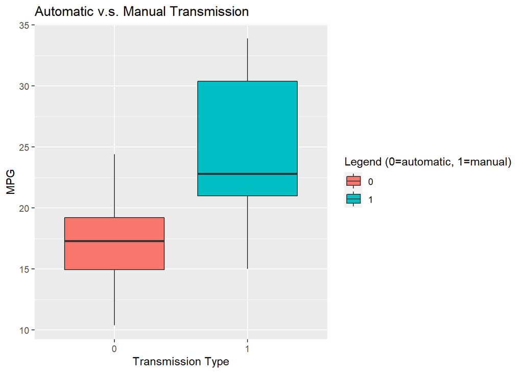

```r
#plot
library(ggplot2)
mtcars$am <- as.factor(mtcars$am)

plot <- ggplot(aes(x=am, y=mpg), data=mtcars) + geom_boxplot(aes(fill=am))
plot <- plot + labs(title = "Automatic v.s. Manual Transmission")
plot <- plot + xlab("Transmission Type")
plot <- plot + ylab("MPG")
plot <- plot + labs(fill = "Legend (0=automatic, 1=manual)")
plot
```

```r
#Hypothesis Test:
auto <- mtcars[mtcars$am == "0",]
manu <- mtcars[mtcars$am == "1",]
t.test(auto$mpg, manu$mpg)
```

```
##
##  Welch Two Sample t-test
##
## data:  auto$mpg and manu$mpg
## t = -3.7671, df = 18.332, p-value = 0.001374
## alternative hypothesis: true difference in means is not equal to 0
## 95 percent confidence interval:
##  -11.280194  -3.209684
## sample estimates:
## mean of x mean of y
##  17.14737  24.39231
```

The boxplot shows that the manual transmission provides substantially higher gas mileage than the automatics. I further test the hypothesis of whether the difference in means are equal. The test result is significant at 95% and the hypothsis is rejected. That is, the means of gas mileage are different based on the transmission types.

## Regression analysis

```
##
## Call:
## lm(formula = mpg ~ am, data = mtcars)
##
## Residuals:
##     Min      1Q  Median      3Q     Max
## -9.3923 -3.0923 -0.2974  3.2439  9.5077
##
## Coefficients:
##             Estimate Std. Error t value Pr(>|t|)
## (Intercept)   17.147      1.125  15.247 1.13e-15 ***
## am1            7.245      1.764   4.106 0.000285 ***
## ---
## Signif. codes:  0 '***' 0.001 '**' 0.01 '*' 0.05 '.' 0.1 ' ' 1
##
## Residual standard error: 4.902 on 30 degrees of freedom
## Multiple R-squared:  0.3598, Adjusted R-squared:  0.3385
## F-statistic: 16.86 on 1 and 30 DF,  p-value: 0.000285
```

```
##
## Call:
## lm(formula = mpg ~ am + cyl, data = mtcars)
##
## Residuals:
##     Min      1Q  Median      3Q     Max
## -5.6856 -1.7172 -0.2657  1.8838  6.8144
##
## Coefficients:
##             Estimate Std. Error t value Pr(>|t|)
## (Intercept)  34.5224     2.6032  13.262 7.69e-14 ***
## am1           2.5670     1.2914   1.988   0.0564 .
## cyl          -2.5010     0.3608  -6.931 1.28e-07 ***
## ---
## Signif. codes:  0 '***' 0.001 '**' 0.01 '*' 0.05 '.' 0.1 ' ' 1
##
## Residual standard error: 3.059 on 29 degrees of freedom
## Multiple R-squared:  0.759,  Adjusted R-squared:  0.7424
## F-statistic: 45.67 on 2 and 29 DF,  p-value: 1.094e-09
```

```
## Analysis of Variance Table
##
## Model 1: mpg ~ am
## Model 2: mpg ~ am + cyl
##   Res.Df    RSS Df Sum of Sq      F    Pr(>F)
## 1     30 720.90
## 2     29 271.36  1    449.53 48.041 1.285e-07 ***
## ---
## Signif. codes:  0 '***' 0.001 '**' 0.01 '*' 0.05 '.' 0.1 ' ' 1
```

```
##
## Call:
## lm(formula = mpg ~ am + cyl + hp, data = mtcars)
##
## Residuals:
##    Min     1Q Median     3Q    Max
## -4.864 -1.811 -0.158  1.492  6.013
##
## Coefficients:
##             Estimate Std. Error t value Pr(>|t|)
## (Intercept) 30.88834    2.78422  11.094 9.27e-12 ***
## am1          3.90428    1.29659   3.011  0.00546 **
## cyl         -1.12721    0.63417  -1.777  0.08636 .
## hp          -0.03688    0.01452  -2.540  0.01693 *
## ---
## Signif. codes:  0 '***' 0.001 '**' 0.01 '*' 0.05 '.' 0.1 ' ' 1
##
## Residual standard error: 2.807 on 28 degrees of freedom
## Multiple R-squared:  0.8041, Adjusted R-squared:  0.7831
## F-statistic: 38.32 on 3 and 28 DF,  p-value: 4.791e-10
```

```
## Analysis of Variance Table
##
## Model 1: mpg ~ am
## Model 2: mpg ~ am + cyl + hp
##   Res.Df    RSS Df Sum of Sq     F    Pr(>F)
## 1     30 720.90
## 2     28 220.55  2    500.34 31.76 6.294e-08 ***
## ---
## Signif. codes:  0 '***' 0.001 '**' 0.01 '*' 0.05 '.' 0.1 ' ' 1
```

```
##
## Call:
## lm(formula = mpg ~ am + cyl + hp + wt, data = mtcars)
##
## Residuals:
##     Min      1Q  Median      3Q     Max
## -3.4765 -1.8471 -0.5544  1.2758  5.6608
##
## Coefficients:
##             Estimate Std. Error t value Pr(>|t|)
## (Intercept) 36.14654    3.10478  11.642 4.94e-12 ***
## am1          1.47805    1.44115   1.026   0.3142
## cyl         -0.74516    0.58279  -1.279   0.2119
## hp          -0.02495    0.01365  -1.828   0.0786 .
## wt          -2.60648    0.91984  -2.834   0.0086 **
## ---
## Signif. codes:  0 '***' 0.001 '**' 0.01 '*' 0.05 '.' 0.1 ' ' 1
##
## Residual standard error: 2.509 on 27 degrees of freedom
## Multiple R-squared:  0.849,  Adjusted R-squared:  0.8267
## F-statistic: 37.96 on 4 and 27 DF,  p-value: 1.025e-10
```

```
## Analysis of Variance Table
##
## Model 1: mpg ~ am
## Model 2: mpg ~ am + cyl + hp + wt
##   Res.Df   RSS Df Sum of Sq      F    Pr(>F)
## 1     30 720.9
## 2     27 170.0  3     550.9 29.166 1.274e-08 ***
## ---
## Signif. codes:  0 '***' 0.001 '**' 0.01 '*' 0.05 '.' 0.1 ' ' 1
```

```
##
## Call:
## lm(formula = mpg ~ am + cyl + hp + wt + vs, data = mtcars)
##
## Residuals:
##     Min      1Q  Median      3Q     Max
## -3.6729 -1.6583 -0.4297  1.3307  5.4688
##
## Coefficients:
##             Estimate Std. Error t value Pr(>|t|)
## (Intercept) 33.24160    5.48527   6.060 2.11e-06 ***
## am1          1.97575    1.64825   1.199   0.2415
## cyl         -0.40179    0.79364  -0.506   0.6169
## hp          -0.02589    0.01387  -1.866   0.0733 .
## wt          -2.54332    0.93506  -2.720   0.0115 *
## vs           1.17067    1.81283   0.646   0.5241
## ---
## Signif. codes:  0 '***' 0.001 '**' 0.01 '*' 0.05 '.' 0.1 ' ' 1
##
## Residual standard error: 2.537 on 26 degrees of freedom
## Multiple R-squared:  0.8514, Adjusted R-squared:  0.8228
## F-statistic:  29.8 on 5 and 26 DF,  p-value: 5.571e-10
```

```
## Analysis of Variance Table
##
## Model 1: mpg ~ am
## Model 2: mpg ~ am + cyl + hp + wt + vs
##   Res.Df    RSS Df Sum of Sq      F    Pr(>F)
## 1     30 720.90
## 2     26 167.31  4    553.58 21.506 6.227e-08 ***
## ---
## Signif. codes:  0 '***' 0.001 '**' 0.01 '*' 0.05 '.' 0.1 ' ' 1
```

```
## Analysis of Variance Table
##
## Model 1: mpg ~ am + cyl + hp + wt
## Model 2: mpg ~ am + cyl + hp + wt + vs
##   Res.Df    RSS Df Sum of Sq     F Pr(>F)
## 1     27 170.00
## 2     26 167.31  1    2.6836 0.417 0.5241
```

The simple linear regression model (model 1) shows that the manual transmissions performs 7.25mpg (Miles/(US) gallon) higher than automatic ones. However, this model explains merely 36% of the MPG performance.  
I move on by adding other variables that might affect a vehicle’s gas mileage. For example, number of cylinders (cyl), engine gross horsepower (hp), vehicle weight (wt), and the engine shape (vs) into the model. As shown by the results, each of these models is able to explain at least 74% of the outcome, which is better than the simple linear regression model. Based on the anova tests, I would choose the model fit4 (with explanatory variables “Transmission”, “Number of cylinders”, “Gross horsepower”, and “Weight”) as the proposed model, although the transmission type is not significant.

## Appendix: Residual plot and diagnostics

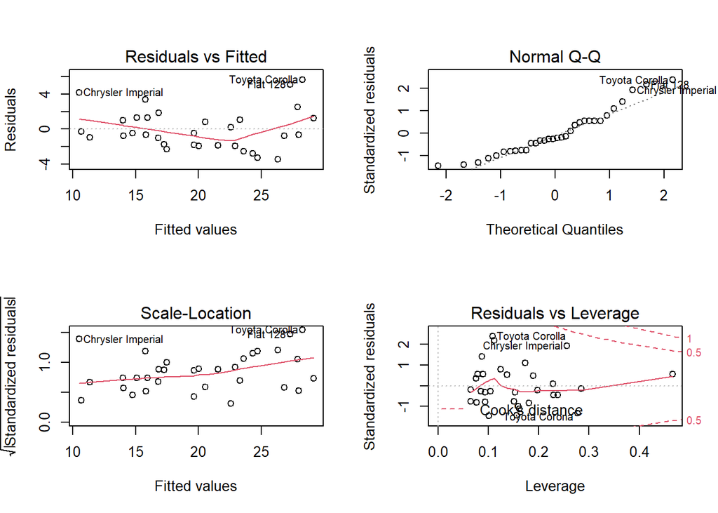

```r
#Scatterplots of the multivariable regression model residuals (model fit4):
par(mfrow = c(2,2))
plot(fit4)
```